# IODS course project

Correlations between variables using correlation matrix plot:

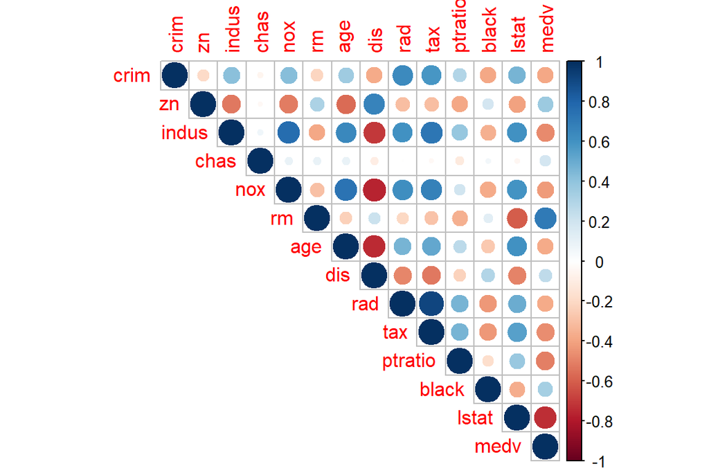

```
##          crim    zn indus  chas   nox    rm   age   dis   rad   tax
## crim     1.00 -0.20  0.41 -0.06  0.42 -0.22  0.35 -0.38  0.63  0.58
## zn      -0.20  1.00 -0.53 -0.04 -0.52  0.31 -0.57  0.66 -0.31 -0.31
## indus    0.41 -0.53  1.00  0.06  0.76 -0.39  0.64 -0.71  0.60  0.72
## chas    -0.06 -0.04  0.06  1.00  0.09  0.09  0.09 -0.10 -0.01 -0.04
## nox      0.42 -0.52  0.76  0.09  1.00 -0.30  0.73 -0.77  0.61  0.67
## rm      -0.22  0.31 -0.39  0.09 -0.30  1.00 -0.24  0.21 -0.21 -0.29
## age      0.35 -0.57  0.64  0.09  0.73 -0.24  1.00 -0.75  0.46  0.51
## dis     -0.38  0.66 -0.71 -0.10 -0.77  0.21 -0.75  1.00 -0.49 -0.53
## rad      0.63 -0.31  0.60 -0.01  0.61 -0.21  0.46 -0.49  1.00  0.91
## tax      0.58 -0.31  0.72 -0.04  0.67 -0.29  0.51 -0.53  0.91  1.00
## ptratio  0.29 -0.39  0.38 -0.12  0.19 -0.36  0.26 -0.23  0.46  0.46
## black   -0.39  0.18 -0.36  0.05 -0.38  0.13 -0.27  0.29 -0.44 -0.44
## lstat    0.46 -0.41  0.60 -0.05  0.59 -0.61  0.60 -0.50  0.49  0.54
## medv    -0.39  0.36 -0.48  0.18 -0.43  0.70 -0.38  0.25 -0.38 -0.47
##         ptratio black lstat  medv
## crim       0.29 -0.39  0.46 -0.39
## zn        -0.39  0.18 -0.41  0.36
## indus      0.38 -0.36  0.60 -0.48
## chas      -0.12  0.05 -0.05  0.18
## nox        0.19 -0.38  0.59 -0.43
## rm        -0.36  0.13 -0.61  0.70
## age        0.26 -0.27  0.60 -0.38
## dis       -0.23  0.29 -0.50  0.25
## rad        0.46 -0.44  0.49 -0.38
## tax        0.46 -0.44  0.54 -0.47
## ptratio    1.00 -0.18  0.37 -0.51
## black     -0.18  1.00 -0.37  0.33
## lstat      0.37 -0.37  1.00 -0.74
## medv      -0.51  0.33 -0.74  1.00
```

```r
library(corrplot)
library(tidyverse)
#  First calculate the correlation matrix
corr_matrix <- cor(Boston)%>% round(2)
# Set margin
par(mfrow = c(1,1))

# visualize the correlation matrix
corrplot(corr_matrix, method="circle", type = "upper", tl.cex = 1) %>% round(2)
```

Correlation Matrices

1. crim are highly correlated to rad, moderately to to indu, nox, age, tax, aptratio and Istat but negatively to zn, rm,dis and medv
2. medv is positively correlated with black, dis, rm, chas, zn medv and negatively correlated to indus, nox, age, rad, tax, ptratio, lstat
3. The highest positive correlations are between “rad” and “tax”, “indux” and “nox” and negative between “dis” and “age” and “dis” and “nox”.

**Data standardization**

Boston data contains numerical values, thus we can use the function *scale()* to standardize the whole dataset.

```r
# center and standardize variables using scale()
boston_scaled <- scale(Boston)

# summaries of the scaled variables
summary(boston_scaled)
```

```
##       crim                 zn               indus
##  Min.   :-0.419367   Min.   :-0.48724   Min.   :-1.5563
##  1st Qu.:-0.410563   1st Qu.:-0.48724   1st Qu.:-0.8668
##  Median :-0.390280   Median :-0.48724   Median :-0.2109
##  Mean   : 0.000000   Mean   : 0.00000   Mean   : 0.0000
##  3rd Qu.: 0.007389   3rd Qu.: 0.04872   3rd Qu.: 1.0150
##  Max.   : 9.924110   Max.   : 3.80047   Max.   : 2.4202
##       chas              nox                rm               age
##  Min.   :-0.2723   Min.   :-1.4644   Min.   :-3.8764   Min.   :-2.3331
##  1st Qu.:-0.2723   1st Qu.:-0.9121   1st Qu.:-0.5681   1st Qu.:-0.8366
##  Median :-0.2723   Median :-0.1441   Median :-0.1084   Median : 0.3171
##  Mean   : 0.0000   Mean   : 0.0000   Mean   : 0.0000   Mean   : 0.0000
##  3rd Qu.:-0.2723   3rd Qu.: 0.5981   3rd Qu.: 0.4823   3rd Qu.: 0.9059
##  Max.   : 3.6648   Max.   : 2.7296   Max.   : 3.5515   Max.   : 1.1164
##       dis               rad               tax             ptratio
##  Min.   :-1.2658   Min.   :-0.9819   Min.   :-1.3127   Min.   :-2.7047
##  1st Qu.:-0.8049   1st Qu.:-0.6373   1st Qu.:-0.7668   1st Qu.:-0.4876
##  Median :-0.2790   Median :-0.5225   Median :-0.4642   Median : 0.2746
##  Mean   : 0.0000   Mean   : 0.0000   Mean   : 0.0000   Mean   : 0.0000
##  3rd Qu.: 0.6617   3rd Qu.: 1.6596   3rd Qu.: 1.5294   3rd Qu.: 0.8058
##  Max.   : 3.9566   Max.   : 1.6596   Max.   : 1.7964   Max.   : 1.6372
##      black             lstat              medv
##  Min.   :-3.9033   Min.   :-1.5296   Min.   :-1.9063
##  1st Qu.: 0.2049   1st Qu.:-0.7986   1st Qu.:-0.5989
##  Median : 0.3808   Median :-0.1811   Median :-0.1449
##  Mean   : 0.0000   Mean   : 0.0000   Mean   : 0.0000
##  3rd Qu.: 0.4332   3rd Qu.: 0.6024   3rd Qu.: 0.2683
##  Max.   : 0.4406   Max.   : 3.5453   Max.   : 2.9865
```

```r
# check the class of the boston_scaled object
class(boston_scaled)
```

```
## [1] "matrix"
```

```r
# change the object to data frame
boston_scaled <- as.data.frame(boston_scaled)
```

Create a categorical variable of the crime rate in the Boston dataset using the scaled crime rate.

```r
# First create a quantile vector of crim
bins <- quantile(boston_scaled$crim)

# create a categorical variable 'crime' into "low", "med_low", "med_high" and "high"
crime <- cut(boston_scaled$crim, breaks = bins, include.lowest = TRUE, label=c("low", "med_low", "med_high", "high"))
```

Drop the old crime rate variable from the dataset.

```r
# remove original crim from the dataset
boston_scaled <- dplyr::select(boston_scaled, -crim) %>% round(2)# round it to 2 decimal places

# add the new categorical value to scaled data
boston_scaled <- data.frame(boston_scaled, crime)
```

Split the data into training and test set so that 80% of the data belongs to the train set and 20% in the test dataset.

```r
# Get the number of rows in the Boston dataset and assign it as *n*
n <- nrow(boston_scaled)

# Select randomly 80% of the rows
ind <- sample(n,  size = n * 0.8)

# Use the selected to create train set
train_data <- boston_scaled[ind,]

# create test set using the remaining rows
test_data  <- boston_scaled[-ind,]
```

**Linear Discriminant analysis**

```r
# linear discriminant analysis
# the dot means all other variables in the data.
lda.fit <- lda(crime ~ ., data = train_data)
# print the lda.fit object
lda.fit
```

```
## Call:
## lda(crime ~ ., data = train_data)
##
## Prior probabilities of groups:
##       low   med_low  med_high      high
## 0.2524752 0.2524752 0.2450495 0.2500000
##
## Group means:
##                  zn      indus          chas        nox         rm
## low       1.0422549 -0.9368627 -0.1544117647 -0.9059804  0.4653922
## med_low  -0.1068627 -0.3282353 -0.0002941176 -0.5749020 -0.1164706
## med_high -0.3752525  0.1398990  0.2460606061  0.3665657  0.1871717
## high     -0.4900000  1.0121782 -0.1532673267  1.0568317 -0.3951485
##                 age        dis        rad        tax     ptratio
## low      -0.8717647  0.9578431 -0.6991176 -0.7366667 -0.44284314
## med_low  -0.3115686  0.3524510 -0.5459804 -0.5167647 -0.07852941
## med_high  0.4269697 -0.3641414 -0.4486869 -0.3619192 -0.33808081
## high      0.8433663 -0.8560396  1.6384158  1.5145545  0.78485149
##               black       lstat        medv
## low       0.3812745 -0.77509804  0.53362745
## med_low   0.3218627 -0.14931373  0.02823529
## med_high  0.1057576 -0.03989899  0.22040404
## high     -0.6937624  0.89415842 -0.70435644
##
## Coefficients of linear discriminants:
##                 LD1         LD2          LD3
## zn       0.06145309  0.69027056 -0.976575706
## indus    0.09065977 -0.24876639  0.237265851
## chas    -0.13066168 -0.12368371  0.058749562
## nox      0.34161524 -0.73721509 -1.422321349
## rm      -0.14798121 -0.10317622 -0.200253740
## age      0.15073965 -0.32885101 -0.268749989
## dis     -0.10691873 -0.20173767 -0.008291818
## rad      3.68255926  0.91035411  0.093657560
## tax      0.05638866  0.02889410  0.380169094
## ptratio  0.09005107  0.05118612 -0.293898096
## black   -0.10460125  0.04783238  0.134565563
## lstat    0.22785212 -0.15415046  0.475319121
## medv     0.20209119 -0.32144803 -0.096794251
##
## Proportion of trace:
##    LD1    LD2    LD3
## 0.9566 0.0325 0.0108
```

The Group means shows the mean of each variable in each group.

Coefficients of linear discriminants provided the linear combination of predictor variables that are used to form the LDA

The “proportion of trace” shown when you print *lda.fit* is the percentage separation achieved by each discriminant function. Thus, the percentage of classification achieved by the first discriminant function (LD1) is 96%, which is very high, While the second (3.3% ) and the third (1.1%) are very low

**Draw the LDA (bi)plot**

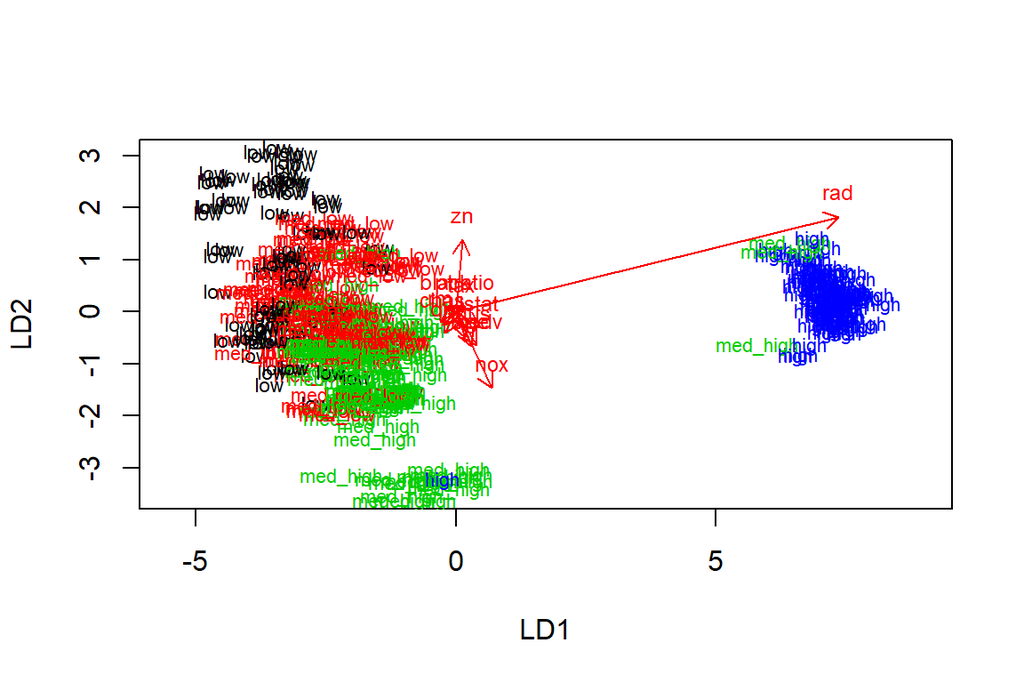

```r
# the function for lda biplot arrows
lda.arrows <- function(x, myscale = 1, arrow_heads = 0.1, color = "red", tex = 0.75, choices = c(1,2)){
  heads <- coef(x)
  arrows(x0 = 0, y0 = 0,
         x1 = myscale * heads[,choices[1]],
         y1 = myscale * heads[,choices[2]], col=color, length = arrow_heads)
  text(myscale * heads[,choices], labels = row.names(heads),
       cex = tex, col=color, pos=3)
}

# target classes as numeric
classes <- as.numeric(train_data$crime)

# plot the lda results
plot(lda.fit, dimen = 2, col = classes, pch = classes)
lda.arrows(lda.fit, myscale = 2)
```

Save the crime categories from the test set and then remove the categorical crime variable from the test dataset

```r
# save the correct classes from test data
correct_classes <- test_data$crime

# remove the crime variable from test data
test_data <- dplyr::select(test_data, -crime)
```

** Make predictions**

```r
# predict classes with test data
lda.pred <- predict(lda.fit, newdata = test_data)

# cross tabulate the results
tab <- table(correct = correct_classes, predicted = lda.pred$class)
tab
```

```
##           predicted
## correct    low med_low med_high high
##   low       11      13        1    0
##   med_low    4      14        6    0
##   med_high   1       8       15    3
##   high       0       0        0   26
```

Overall we assess the model accuracy

** Model accuracy**

Compute the model accuracy as follow:

```r
sum(diag(tab))/sum(tab)
```

```
## [1] 0.6470588
```

** Distance measures**

```r
# load MASS and Boston
library(MASS)
data('Boston')
```

Standardize the data

```r
# center and standardize variables using scale()
boston_scaled <- scale(Boston)

# summaries of the scaled variables
summary(boston_scaled)
```

```
##       crim                 zn               indus
##  Min.   :-0.419367   Min.   :-0.48724   Min.   :-1.5563
##  1st Qu.:-0.410563   1st Qu.:-0.48724   1st Qu.:-0.8668
##  Median :-0.390280   Median :-0.48724   Median :-0.2109
##  Mean   : 0.000000   Mean   : 0.00000   Mean   : 0.0000
##  3rd Qu.: 0.007389   3rd Qu.: 0.04872   3rd Qu.: 1.0150
##  Max.   : 9.924110   Max.   : 3.80047   Max.   : 2.4202
##       chas              nox                rm               age
##  Min.   :-0.2723   Min.   :-1.4644   Min.   :-3.8764   Min.   :-2.3331
##  1st Qu.:-0.2723   1st Qu.:-0.9121   1st Qu.:-0.5681   1st Qu.:-0.8366
##  Median :-0.2723   Median :-0.1441   Median :-0.1084   Median : 0.3171
##  Mean   : 0.0000   Mean   : 0.0000   Mean   : 0.0000   Mean   : 0.0000
##  3rd Qu.:-0.2723   3rd Qu.: 0.5981   3rd Qu.: 0.4823   3rd Qu.: 0.9059
##  Max.   : 3.6648   Max.   : 2.7296   Max.   : 3.5515   Max.   : 1.1164
##       dis               rad               tax             ptratio
##  Min.   :-1.2658   Min.   :-0.9819   Min.   :-1.3127   Min.   :-2.7047
##  1st Qu.:-0.8049   1st Qu.:-0.6373   1st Qu.:-0.7668   1st Qu.:-0.4876
##  Median :-0.2790   Median :-0.5225   Median :-0.4642   Median : 0.2746
##  Mean   : 0.0000   Mean   : 0.0000   Mean   : 0.0000   Mean   : 0.0000
##  3rd Qu.: 0.6617   3rd Qu.: 1.6596   3rd Qu.: 1.5294   3rd Qu.: 0.8058
##  Max.   : 3.9566   Max.   : 1.6596   Max.   : 1.7964   Max.   : 1.6372
##      black             lstat              medv
##  Min.   :-3.9033   Min.   :-1.5296   Min.   :-1.9063
##  1st Qu.: 0.2049   1st Qu.:-0.7986   1st Qu.:-0.5989
##  Median : 0.3808   Median :-0.1811   Median :-0.1449
##  Mean   : 0.0000   Mean   : 0.0000   Mean   : 0.0000
##  3rd Qu.: 0.4332   3rd Qu.: 0.6024   3rd Qu.: 0.2683
##  Max.   : 0.4406   Max.   : 3.5453   Max.   : 2.9865
```

```r
# change the object to data frame
boston_scaled <- as.data.frame(boston_scaled)
```

Calculate the distances between the observations.

```r
# euclidean distance matrix (the Euclidean method is the default one)
dist_eu <- dist(boston_scaled)

# look at the summary of the distances
summary(dist_eu )
```

```
##    Min. 1st Qu.  Median    Mean 3rd Qu.    Max.
##  0.1343  3.4625  4.8241  4.9111  6.1863 14.3970
```